# 기말프로젝트

G202358002 서예지

2024-06-20

## 1번.

```r
# SIR 모델 시뮬레이션 함수
simulate_SIR <- function(N, a, t) {
  total <- rep(0, N)
  first <- sample(1:N, 1, replace = FALSE)
  total[first] <- 1

  I <- numeric(t)
  S <- numeric(t)

  I[1] <- sum(total == 1)
  S[1] <- sum(total == 0)

  for (time in 2:t) {
    # 접촉이 이루어질 두 사람 선정
    contacts <- sample(1:N, 2, replace = FALSE)

    if (sum(total[contacts]) == 1) {
      if (runif(1) < a) {
        total[contacts] <- 1
      }
    }
    # 감염자 및 건강한 사람 수 업데이트
    I[time] <- sum(total == 1)
    S[time] <- sum(total == 0)

  }
  return(list(S = S, I = I))
}

N <- 1000
a <- 0.1
t<- 100000

sir <- simulate_SIR(N, a, t)
time_1000 <- which(sir$I >= 1000)[1]

# 감염과정
df <- data.frame(Time = 1:100000, Susceptible = sir$S, Infected = sir$I)

# 1000명이 감염될 때까지의 시간
cat("1000명이 감염될 때까지 걸린 시간:", time_1000, "일\n")
```

```
## 1000명이 감염될 때까지 걸린 시간: 80415 일
```

```r
# SIR 모델 시뮬레이션 함수
simulate_SIR <- function(N, a, b, t) {
  total <- rep(0, N)
  first <- sample(1:N, 10, replace = FALSE)
  total[first] <- 1

  I <- numeric(t)
  S <- numeric(t)

  I[1] <- sum(total == 1)
  S[1] <- sum(total == 0)

  for (time in 2:t) {
    # 접촉이 이루어질 두 사람 선정
    contacts <- sample(1:N, 2, replace = FALSE)

    if (sum(total[contacts]) == 1) {
      if (runif(1) < a) {
        total[contacts] <- 1
      }
    }
    total[total == 1] <- rbinom(sum(total==1),1,1-b)
    # 감염자 및 건강한 사람 수 업데이트
    I[time] <- sum(total == 1)
    S[time] <- sum(total == 0)

  }
  return(list(S = S, I = I))
}

N <- 100
a <- 0.1
t<- 100000
b <- 0.01

sir <- simulate_SIR(N, a, b, t)
# 감염과정
df <- data.frame(Time = 1:100000, Susceptible = sir$S, Infected = sir$I)
```

(c)-(a). 접촉간 시간이 평균 5인 지수분포인 경우에 대하여 (a)를 실시한 결과이다. (a)에서보다 감염 확산이 느려졌다.

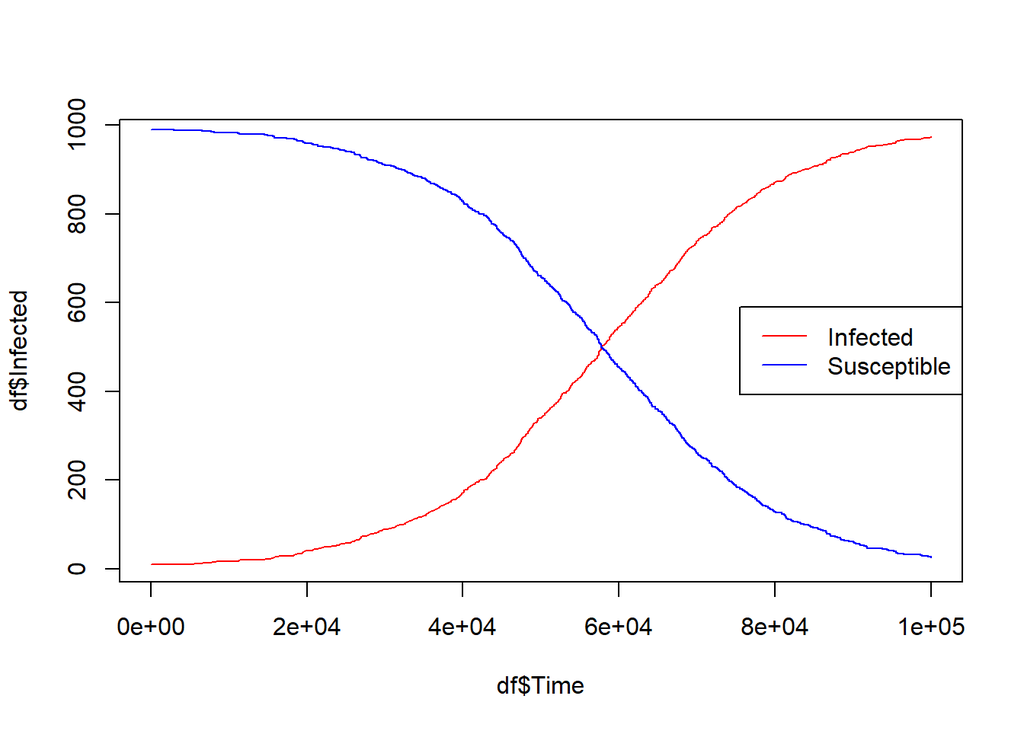

```r
# SIR 모델 시뮬레이션 함수
simulate_SIR<- function(N, a, t, lambda, start) {
  total <- rep(0, N)
  initial <- sample(1:N, 10, replace = FALSE)
  total[initial] <- 1

  I <- numeric(t)
  S <- numeric(t)

  I[1] <- sum(total == 1)
  S[1] <- sum(total == 0)

  for (time in 2:t) {
    # 접촉 횟수를 포아송 분포로 결정
    exp_Contacts <- rpois(1, lambda = 1 / lambda)

    if (exp_Contacts > 0) {
      for (contact in 1:exp_Contacts) {
        contacts <- sample(1:N, 2, replace = FALSE)

        if (sum(total[contacts]) == 1) {
          if (runif(1) < a) {
            total[contacts] <- 1
          }
        }
      }
    }

    # 감염자 및 건강한 사람 수 업데이트
    I[time] <- sum(total == 1)
    S[time] <- sum(total == 0)
  }

  return(list(S = S, I = I))
}

N <- 1000
a <- 0.2
t <- 100000
lambda <- 5

sir <- simulate_SIR(N, a, t, lambda, start)

# 감염과정
df <- data.frame(Time = 1:100000, Susceptible = sir$S, Infected = sir$I)

# 그래프 출력
plot(df$Time, df$Infected, type = 'l', col = 'red')
lines(df$Time, df$Susceptible, type = 'l',col = 'blue')
legend("right", legend = c("Infected", "Susceptible"), col = c("red", "blue"), lty = 1)
```

(c)-(b). 접촉간 시간이 평균 5인 지수분포인 경우에 대하여 (b)를 실시한 결과이다.

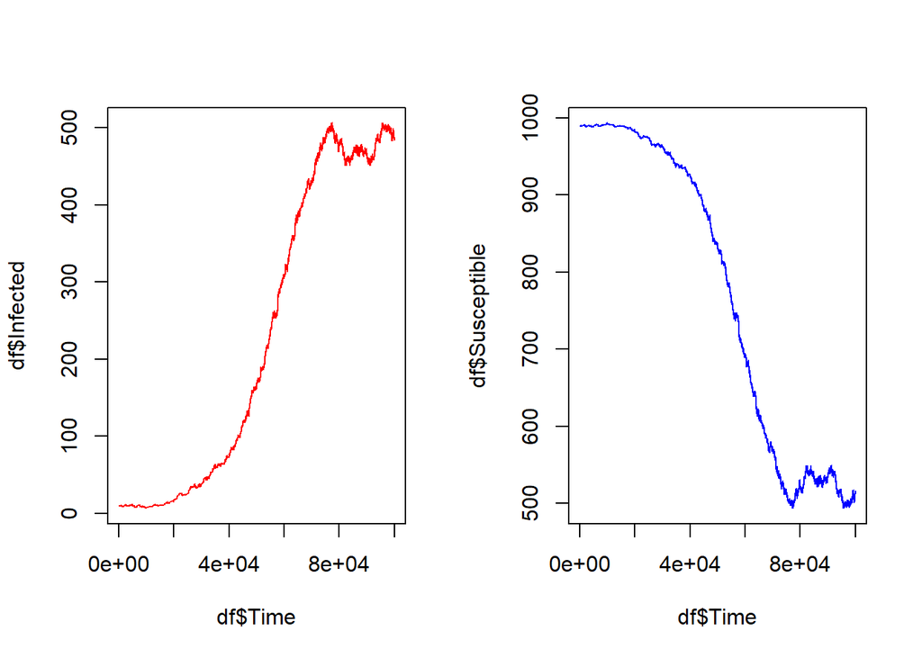

```r
# SIR 모델 시뮬레이션 함수
simulate_SIR <- function(N, a, b, t) {
  total <- rep(0, N)
  first <- sample(1:N, 10, replace = FALSE)
  total[first] <- 1

  I <- numeric(t)
  S <- numeric(t)

  I[1] <- sum(total == 1)
  S[1] <- sum(total == 0)

  for (time in 2:t) {
    # 접촉 횟수를 포아송 분포로 결정
    exp_Contacts <- rpois(1, lambda = 1 / lambda)

    if (exp_Contacts > 0) {
      for (contact in 1:exp_Contacts) {
        contacts <- sample(1:N, 2, replace = FALSE)

        if (sum(total[contacts]) == 1) {
          if (runif(1) < a) {
            total[contacts] <- 1
          }
        }
      }
    }

    total[total == 1] <- rbinom(sum(total==1),1,1-b)
    # 감염자 및 건강한 사람 수 업데이트
    I[time] <- sum(total == 1)
    S[time] <- sum(total == 0)

  }
  return(list(S = S, I = I))
}

N <- 1000
a <- 0.5
t<- 100000
b <- 0.0001
lambda <- 5

sir <- simulate_SIR(N, a, b, t)

# 감염과정
df <- data.frame(Time = 1:100000, Susceptible = sir$S, Infected = sir$I)

# 그래프 출력
par(mfrow=c(1,2))
plot(df$Time, df$Infected, type = 'l', col = 'red')
plot(df$Time, df$Susceptible, type = 'l',col = 'blue')
```

## 2번.

1. $\mu,\sigma^2$을 각각 두 수준씩 잡고 그래프로 그려본 결과는 다음과 같다. $\mu$를 동일하게 하고 $\sigma^2$을 각각 0.01, 0.05로 설정하였을 때, $\sigma^2$이 작은 경우에 변동성이 작으므로 등락폭이 크지 않은 결과를 볼 수 있었고, 반대로 $\sigma^2$이 큰 경우에는 변동성이 크므로 주가의 변동이 크고 상승과 하락을 반복하며 등락폭이 큰 경향을 볼 수 있었다. 즉, $\sigma^2$이 클수록 주가 변동성이 커져 risk가 증가함을 의미한다. 또한, $\sigma^2$을 동일하게 하고 $\mu$를 각각 0.05, 0.1로 설정하였 때, $\mu$가 클수록 주가는 평균적으로 더 높은 속도로 상승하는 경향이 있음을 알 수 있다.

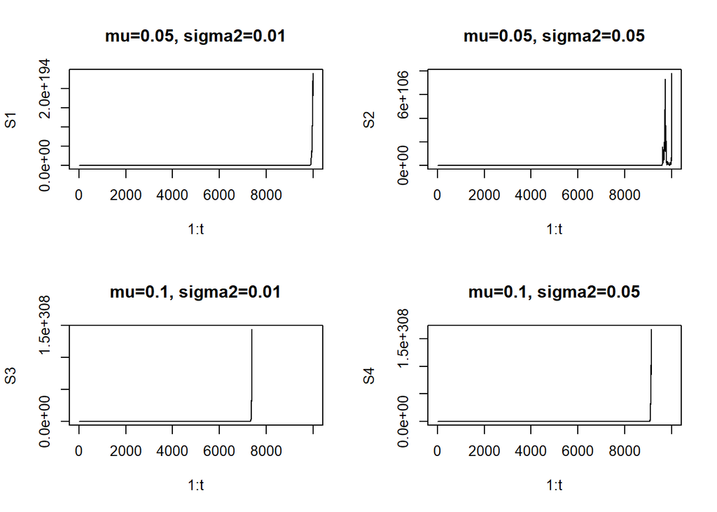

```r
# 함수 정의
sim <- function(mu, sigma2, S0, t) {
  N <- t
  S <- numeric(N)
  S[1] <- S0

  for (i in 2:N) {
    Z <- rnorm(1,mean=0,sd=1)
    S[i] <- S[i-1] * exp((mu - sigma2/2) + sqrt(sigma2) * Z)
  }

  return(S)
}

mu1 <- 0.05; sigma1 <- 0.01
mu2 <- 0.1; sigma2 <- 0.05
S0 <- 100; t <- 10000

# 각 모수 조합에 대한 주가
S1 <- sim(mu1, sigma1, S0, t)
S2 <- sim(mu1, sigma2, S0, t)
S3 <- sim(mu2, sigma1, S0, t)
S4 <- sim(mu2, sigma2, S0, t)

# 그래프 출력
par(mfrow=c(2,2))
plot(1:t, S1, type="l", main=paste0("mu=", mu1, ", sigma2=", sigma1))
plot(1:t, S2, type="l", main=paste0("mu=", mu1, ", sigma2=", sigma2))
plot(1:t, S3, type="l", main=paste0("mu=", mu2, ", sigma2=", sigma1))
plot(1:t, S4, type="l", main=paste0("mu=", mu2, ", sigma2=", sigma2))
```

2. 세 조합에 대하여 $E[S(t)]$와 $P(S(t)>S(0))$를 추정하고 각 추정치의 95% 신뢰구간을 구한 결과는 다음과 같다.

```r
sim <- function(mu, sigma2, S0, t) {
  N <- t
  S <- numeric(N)
  S[1] <- S0

  for (i in 2:N) {
    Z <- rnorm(1, mean = 0, sd = 1)
    S[i] <- S[i - 1] * exp((mu - sigma2 / 2) + sqrt(sigma2) * Z)
  }

  return(S)
}

# (mu, sigma^2)의 세 조합
params <- list(
  list(mu = 0.05, sigma2 = 0.0025),
  list(mu = 0.01, sigma2 = 0.0025),
  list(mu = 0.01, sigma2 = 0.01)
)

# 추정치 계산
estimate_mean_prob <- function(mu, sigma2, S0, t, B = 5000) {
  S_t <- sim(mu, sigma2, S0, t)
  exp_mu_t <- exp(mu * t)
  mean_est <- mean(S_t)
  prob_est <- mean(S_t > S0)

  boot_means <- numeric(B)
  boot_probs <- numeric(B)

  for (i in 1:B) {
    boot_sample <- sample(S_t, replace = TRUE)
    boot_means[i] <- mean(boot_sample)
    boot_probs[i] <- mean(boot_sample > S0)
  }

  # 95% 신뢰구간 계산
  mean_ci <- quantile(boot_means, c(0.025, 0.975))
  prob_ci <- quantile(boot_probs, c(0.025, 0.975))

  return(list(
    mean_est = mean_est,
    exp_mu_t =  exp_mu_t,
    mean_ci = mean_ci,
    prob_est = prob_est,
    prob_ci = prob_ci,
    S_t = S_t
  ))
}

results <- lapply(params, function(param) {
  estimate_mean_prob(param$mu, param$sigma2, S0 = 100, t = 10000)
})

for (i in 1:length(params)) {
  cat("mu =", params[[i]]$mu, ", sigma2 =", params[[i]]$sigma2, "\n")
  cat("exp(mut) =", exp(params[[i]]$mu*10000), "\n")
  cat("E[S(t)]:", results[[i]]$mean_est, "\n")
  cat("95% Confidence Interval for E[S(t)]:", results[[i]]$mean_ci, "\n")
  cat("P(S(t) > S0):", results[[i]]$prob_est, "\n")
  cat("95% Confidence Interval for P(S(t) > S0):", results[[i]]$prob_ci, "\n\n")
}
```

```
## mu = 0.05 , sigma2 = 0.0025
## exp(mut) = 1.403592e+217
## E[S(t)]: 6.27771e+208
## 95% Confidence Interval for E[S(t)]: 4.2868e+208 8.486824e+208
## P(S(t) > S0): 0.9998
## 95% Confidence Interval for P(S(t) > S0): 0.9995 1
##
## mu = 0.01 , sigma2 = 0.0025
## exp(mut) = 2.688117e+43
## E[S(t)]: 3.379075e+37
## 95% Confidence Interval for E[S(t)]: 2.982665e+37 3.801707e+37
## P(S(t) > S0): 0.9965
## 95% Confidence Interval for P(S(t) > S0): 0.9953 0.9976
##
## mu = 0.01 , sigma2 = 0.01
## exp(mut) = 2.688117e+43
## E[S(t)]: 3.283926e+26
## 95% Confidence Interval for E[S(t)]: 2.948467e+26 3.617116e+26
## P(S(t) > S0): 0.9932
## 95% Confidence Interval for P(S(t) > S0): 0.9915 0.9948
```

## 3번.

1. 역변환법을 이용하여 $Pa(3,100000)$분포로부터 난수 10000개를 발생시킨 함수는 다음과 같다.

```r
pa = function(n,a,b){
  num=b/((1-runif(n))^(1/a))
  return(num)
}
rpa=pa(10000,3,100000)
```

히스토그램과 pdf를 겹쳐 그린 결과 아래와 같이 거의 일치함을 알 수 있다.

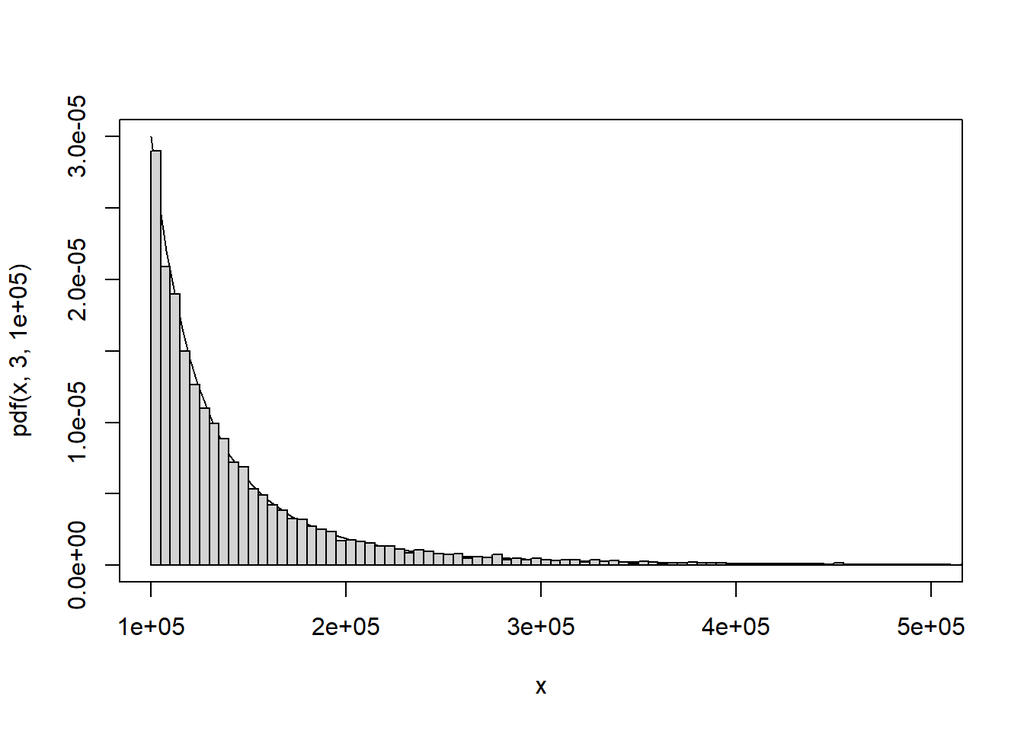

```r
pdf = function(x,a,b){
  return((a*(b^a))/(x^(a+1)))
}
curve(pdf(x,3,100000),xlim=c(100000,500000),type='l')
hist(rpa,breaks=seq(100000,7000000,5000),freq=FALSE,add=TRUE)
```

2. 1000번의 독립적 시행에서 각 시행이 확률 0.01을 가지므로 보험청구 고객수는 이항분포를 따른다. 따라서 반복문을 돌려 $Z(1), ..., Z(5)$를 구할 수 있으므로 이를 이용하여 x축은 년도를 y축은 자산인 plot을 그리면 다음과 같다.

```r
asset <- 1000000
n <- 1000
premium <- 5500
p <- 0.01
alpha <- 3
beta <- 100000
years <- 5

Z <- numeric(years+1)
Z[1] <- asset

for (t in 1:years) {
  if(Z[t] == 0){
    Z[t+1:years+1] <- 0
    next
   }
    N <- rbinom(1, n, p)
    X_t <- sum(pa(N, alpha, beta))
    Z[t+1] <- max(Z[t] + n * premium - X_t, 0)
  }

print(Z)
```

```
## [1]  1000000  5003572  9250181 13243118 16818321 20105896
```

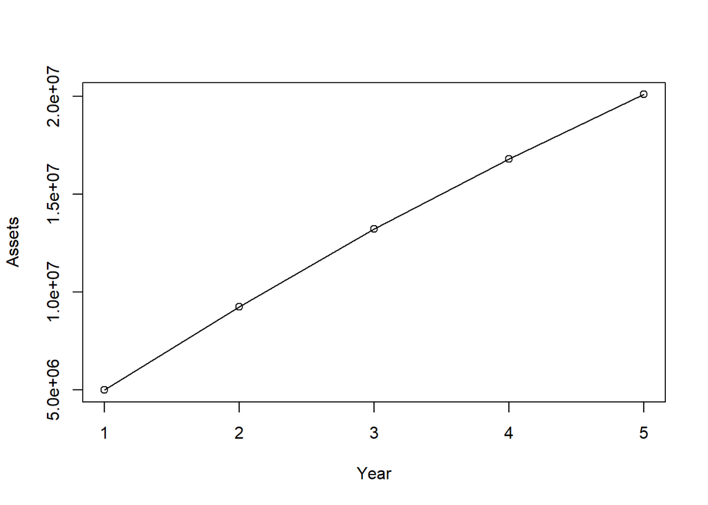

```r
years_vector <- 1:years
plot(years_vector, Z[2:6], type = "o", xlab = "Year", ylab = "Assets")
```

시뮬레이션 횟수를 10000번으로 설정하여 실행하면 회사가 파산할 확률과 5년 후의 자산의 기대값은 다음과 같다.

```r
asset <- 1000000
n <- 1000
premium <- 5500
p <- 0.01
alpha <- 3
beta <- 100000
years <- 5

# 시뮬레이션 횟수
MC <- 10000

last <- numeric(MC)

for (i in 1:MC) {
  Z <- numeric(years+1)
  Z[1] <- asset

  for (t in 1:years) {
    if (Z[t] == 0) {
      Z[(t+1):(years+1)] <- 0  # 파산 시 그 이후 모두 0
      next
    }

    N <- rbinom(1, n, p)
    X_t <- sum(pa(N,alpha, beta))
    Z[t+1] <- max(Z[t] + n * premium - X_t, 0)
  }

  last[i] <- Z[6]
}

# 회사가 파산할 확률
bankruptcy <- mean(last == 0)

# 5년 후의 자산의 기대값
expect <- mean(last)

cat("회사가 파산할 확률:", bankruptcy, "\n")
```

```
## 회사가 파산할 확률: 0
```

```r
cat("5년 후의 자산의 기대값:", expect, "\n")
```

```
## 5년 후의 자산의 기대값: 21007216
```

3. 이익 배당을 하는 경우 회사가 파산할 확률, 5년 후 자산의 기대값, 5년 동안 총 이익배당의 기대값을 추정한 결과는 다음과 같다. (b)의 모의실험에서 얻은 값과 비교하였을 때 회사가 파산할 확률은 약간 증가하나 이익 배당을 하는 경우에 5년 후 자산의 기대값이 확연하게 줄은 것을 알 수 있다.

```r
asset <- 1000000
n <- 1000
premium <- 5500
p <- 0.01
alpha <- 3
beta <- 100000
years <- 5

# 시뮬레이션 횟수
MC <- 10000

last <- numeric(MC)
total_dividends <- numeric(MC)

for (i in 1:MC) {
  Z <- numeric(years + 1)
  Z[1] <- asset
  dividends <- 0

  for (t in 1:years) {
    if (Z[t] == 0) {
      Z[(t + 1):(years + 1)] <- 0  # 파산 시 그 이후 모두 0
      next
    }
    N <- rbinom(1, n, p)
    X_t <- sum(pa(N, alpha, beta))
    Z[t + 1] <- max(Z[t] + n * premium - X_t, 0)

    if (Z[t + 1] > 1000000) {
      dividends <- dividends + (Z[t + 1] - 1000000)
      Z[t + 1] <- Z[t + 1] - (Z[t + 1] - 1000000)
    }

    Z[t + 1] <- max(Z[t + 1], 0)
  }

  last[i] <- Z[6]
  total_dividends[i] <- dividends
}

# 회사가 파산할 확률
bankruptcy <- mean(last == 0)

# 5년 후의 자산의 기대값
expect <- mean(last)

# 5년동안 총 이익배당의 기댓값
expect_dividends <- mean(total_dividends)

cat("회사가 파산할 확률:", bankruptcy, "\n")
```

```
## 회사가 파산할 확률: 8e-04
```

```r
cat("5년 후의 자산의 기대값:", expect, "\n")
```

```
## 5년 후의 자산의 기대값: 999200
```

```r
cat("5년간 총 이익배당의 기댓값:", expect_dividends, "\n")
```

```
## 5년간 총 이익배당의 기댓값: 19991171
```